# PS7-9.Rmd

Joe Margolis

10/15/2020

```r
require(pracma)
```

This is Problem #9 on PS7. The last problem of the course! In it we find a least-squares fit of a parabola to some data. Here is the data, plotted together with the *wrong* parabola. I just guessed.

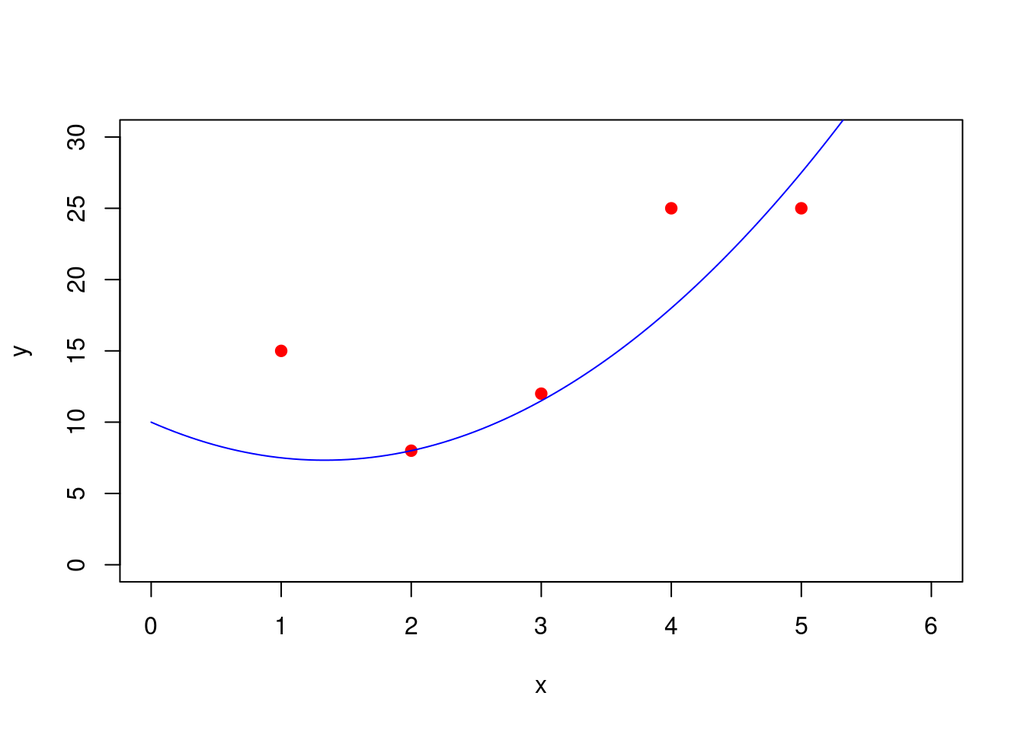

```r
x = c(1,2,3,4,5)
y = c(15, 8, 12, 25, 25)
plot(x,y,pch=19,cex=1,col="red",xlim=c(0,6),ylim=c(0,30),xlab='x',ylab='y')
xx = seq(0,6,len=100)
points(xx, 10 - 4*xx  + 1.5 *xx^2,type='l',col="blue") #the coefficients I used here are wrong
```

The parabola we want to find is of the form $f(x) = a_0 + a_1 x + a_2 x^2$. We’d like the points to all be on he parabla. So, we’d like to solve the following equations:
$$\begin{align*}
a_0 + a_1*1 + a_2*1^2 &= 15 \\
a_0 + a_1*2 + a_2*2^2 &= 8 \\
a_0 + a_1*3 + a_2*3^2 &= 12 \\
a_0 + a_1*4 + a_2*4^2 &= 25 \\
a_0+ a_1*5 + a_2*5^2 &= 25 \\
\end{align*}$$
This is the same as the matrix equation
$$\begin{bmatrix}
1 & 1 & 1 \\
1 & 2 & 4 \\
1 & 3 & 9 \\
1 & 4 & 16 \\
1 & 5 & 25 \\
\end{bmatrix}
\begin{bmatrix} a_0 \\ a_1 \\ a_2 \end{bmatrix}
= \begin{bmatrix} 15 \\ 8 \\ 12 \\ 25 \\ 25 \end{bmatrix}.$$
If we try to solve this we see that it is inconsistent:

```r
A = cbind(x^0,x^1,x^2)
(Ay = cbind(A,y))
```

```
##              y
## [1,] 1 1  1 15
## [2,] 1 2  4  8
## [3,] 1 3  9 12
## [4,] 1 4 16 25
## [5,] 1 5 25 25
```

```r
rref(Ay)
```

```
##            y
## [1,] 1 0 0 0
## [2,] 0 1 0 0
## [3,] 0 0 1 0
## [4,] 0 0 0 1
## [5,] 0 0 0 0
```

You will save the day by finding a least squares solution!

1. First, up and solve the normal equations $A^T A x = A^T y$.

```r
ATA = t(A) %*% A
ATA
```

```
##      [,1] [,2] [,3]
## [1,]    5   15   55
## [2,]   15   55  225
## [3,]   55  225  979
```

```r
ATy = t(A) %*% y
ATy
```

```
##      [,1]
## [1,]   85
## [2,]  292
## [3,] 1180
```

```r
norm = cbind(ATA,ATy)
norm
```

```
##      [,1] [,2] [,3] [,4]
## [1,]    5   15   55   85
## [2,]   15   55  225  292
## [3,]   55  225  979 1180
```

```r
rref(norm)
```

```
##      [,1] [,2] [,3]      [,4]
## [1,]    1    0    0 17.400000
## [2,]    0    1    0 -6.157143
## [3,]    0    0    1  1.642857
```

$\x1 = 17.4$ $\x2 = -6.157143$ $\x3 = 1.642857$

2. Then find the projected value $\hat y = A \hat x$.

```r
xvals = cbind(17.400000,-6.157143,1.642857)
xvals
```

```
##      [,1]      [,2]     [,3]
## [1,] 17.4 -6.157143 1.642857
```

```r
yhat = A %*% t(xvals)
yhat
```

```
##          [,1]
## [1,] 12.88571
## [2,] 11.65714
## [3,] 13.71428
## [4,] 19.05714
## [5,] 27.68571
```

3. Then find the residual

```r
r = y - yhat
r
```

```
##           [,1]
## [1,]  2.114286
## [2,] -3.657142
## [3,] -1.714284
## [4,]  5.942860
## [5,] -2.685710
```

4. Then find the length of the residual

```r
n1 = r[1,] %*% r[1,]
n2 = r[2,] %*% r[2,]
n3 = r[3,] %*% r[3,]
n4 = r[4,] %*% r[4,]
n5 = r[5,] %*% r[5,]
j = n1+n2+n3+n4+n5
lr = sqrt(j)
lr
```

```
##          [,1]
## [1,] 7.957027
```

22. Now fix up the plot. You should only need to change the coordinates on polynomial which right now are incorrectly set at 10, -4, and 1.5.

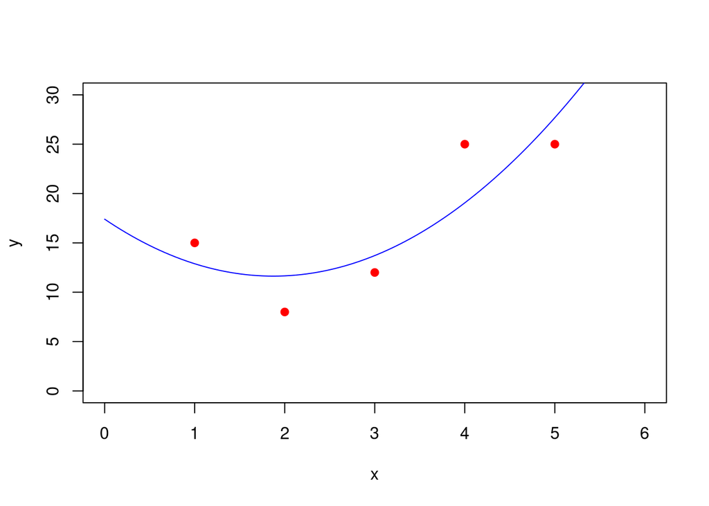

```r
plot(x,y,pch=19,cex=1,col="red",xlim=c(0,6),ylim=c(0,30),xlab='x',ylab='y')
xx = seq(0,6,len=100)
points(xx, 17.400000 - 6.157143*xx  + 1.642857 *xx^2,type='l',col="blue") #the coefficients I used here are wrong
```

6. Explain how you “see” $y$, $\hat y$, and $r$ in your plot.

$y$ is seen in the plot through the y values of each red dot in the plot $\hat y$ is seen in the plot as y values of points on the line of best fit that are the same x value as the red dot at the corresponding x value $r$ is show by the distance in y value from that point along the line previously previously deemed $\hat y$ and the red dot that has the corresponding x-value